## What is mean total number of steps taken per day?

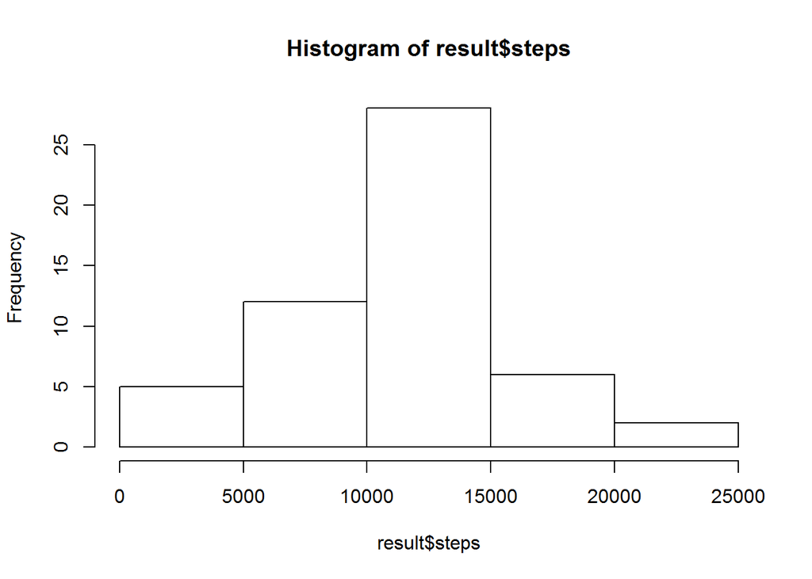

```r
rawdata <- read.csv("activity.csv", na.strings = c("NA"))
result <- aggregate(steps ~ date, data = rawdata, sum)
hist(result$steps)
```

Mean is:

```r
mean(result$steps)
```

```
## [1] 10766.19
```

Median is:

```r
median(result$steps)
```

```
## [1] 10765
```

## What is the average daily activity pattern?

Time series plot of the 5-minute interval (x-axis) and the average number of steps taken, averaged across all days (y-axis)

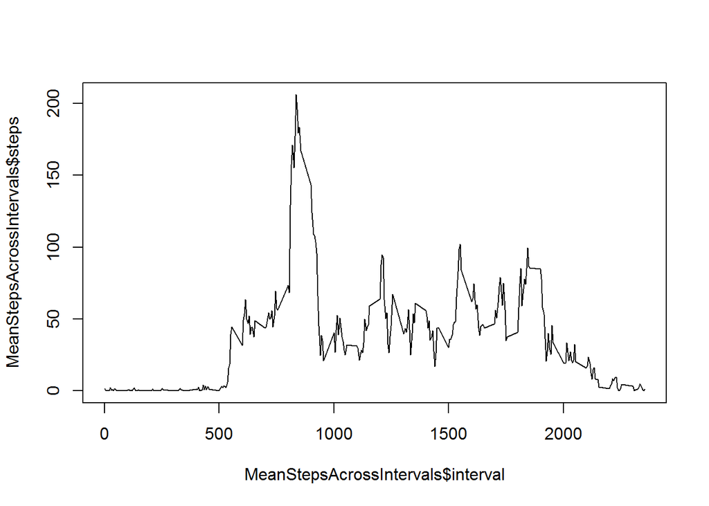

```r
MeanStepsAcrossIntervals <- aggregate(steps ~ interval, data = rawdata, mean)
plot(MeanStepsAcrossIntervals$interval, MeanStepsAcrossIntervals$steps, type = "l")
```

Which 5-minute interval, on average across all the days in the dataset, contains the maximum number of steps?

```r
MeanStepsAcrossIntervals[which.max(MeanStepsAcrossIntervals$steps),"interval"]
```

```
## [1] 835
```

## Imputing missing values

Calculate and report the total number of missing values in the dataset

```r
length(which(is.na(rawdata$steps)))
```

```
## [1] 2304
```

Devise a strategy for filling in all of the missing values in the dataset. Create a new dataset that is equal to the original dataset but with the missing data filled in.

I’ll take means for 5-min intervals as target values.

```r
EnrichedData = cbind(rawdata)
for (row in 1:nrow(EnrichedData)) {
  if (is.na(EnrichedData$steps[row])) {
    matchingdata = which(MeanStepsAcrossIntervals$interval == EnrichedData$interval[row])
    EnrichedData$steps[row] <- MeanStepsAcrossIntervals[matchingdata[1],"steps"]
  }
}
```

Make a histogram of the total number of steps taken each day

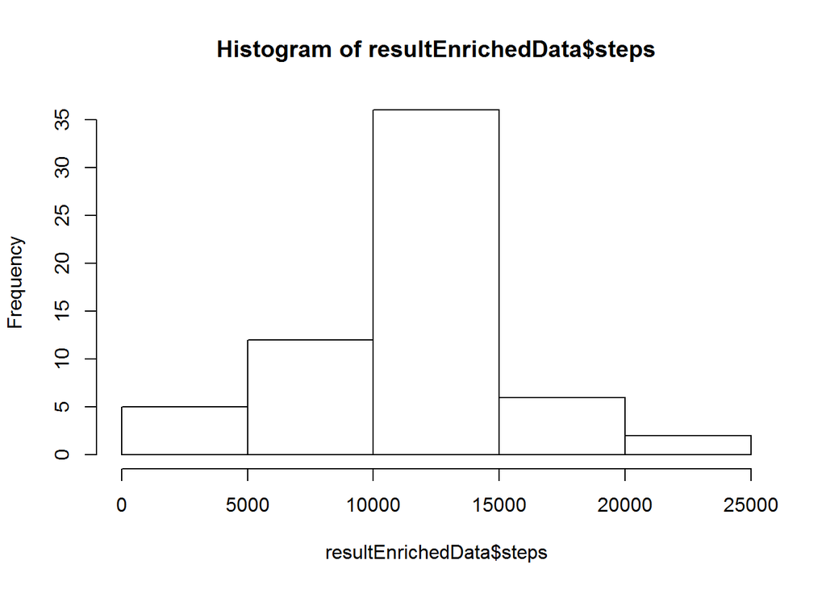

```r
resultEnrichedData <- aggregate(steps ~ date, data = EnrichedData, sum)
hist(resultEnrichedData$steps)
```

Mean is:

```r
mean(resultEnrichedData$steps)
```

```
## [1] 10766.19
```

Median is:

```r
median(resultEnrichedData$steps)
```

```
## [1] 10766.19
```

## Are there differences in activity patterns between weekdays and weekends?

Create a new factor variable in the dataset with two levels – “weekday” and “weekend” indicating whether a given date is a weekday or weekend day.

```r
NewData = cbind(EnrichedData)
NewData$DateAsDate <- strptime(NewData$date, "%Y-%m-%e")
NewData$WeekdayNo <- ifelse(format(NewData$DateAsDate, "%u") %in% c(6,7), "weekend", "weekday")
NewData$WeekdayNo <- factor(NewData$WeekdayNo)
```

Make a panel plot containing a time series plot (i.e. type = “l”) of the 5-minute interval (x-axis) and the average number of steps taken, averaged across all weekday days or weekend days (y-axis).

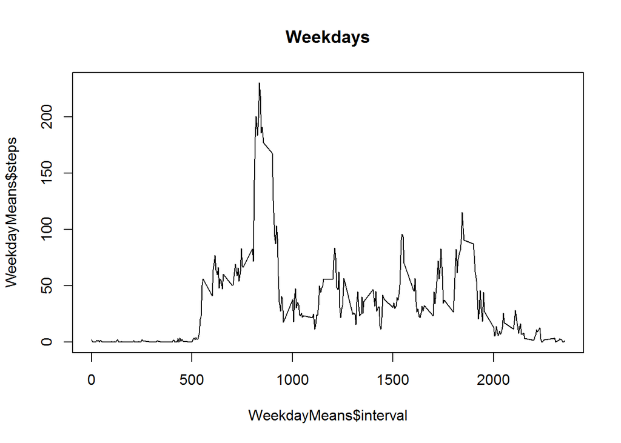

```r
WeekdayMeans <- aggregate(steps ~ interval, data = subset(NewData, WeekdayNo == "weekday"), mean)
plot(WeekdayMeans$interval, WeekdayMeans$steps, type = "l", main = "Weekdays")
```

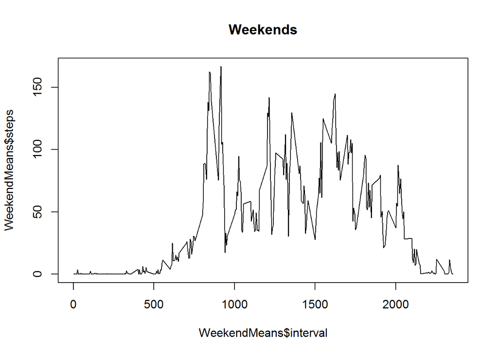

```r
WeekendMeans <- aggregate(steps ~ interval, data = subset(NewData, WeekdayNo == "weekend"), mean)
plot(WeekendMeans$interval, WeekendMeans$steps, type = "l", main = "Weekends")
```